# ggRtsy

Katelyn Diaz, Tess Goldmann, Silas Weden

2025-09-29

## goghColors

```r
knitr::kable(head(goghColors,10))
```

| name | rgb | hex |
| --- | --- | --- |
| Absolute Zero | (0, 72, 186) | #0048ba |
| Acid Green | (176, 191, 26) | #b0bf1a |
| Alice Blue | (240, 248, 255) | #f0f8ff |
| Alizarin | (227, 38, 54) | #e32636 |
| Amaranth | (229, 43, 80) | #e52b50 |
| Amber | (255, 191, 0) | #ffbf00 |
| Amethyst | (153, 102, 204) | #9966cc |
| Antique White | (250, 235, 215) | #faebd7 |
| Antique White | (255, 239, 219) | #ffefdb |
| Antique White | (238, 223, 204) | #eedfcc |

## RectangleFiller()

ggRtsy also has a function that work alongside `ggplot2()` to create more interesting data visualizations and add contextual information to the user’s plots. This main function is `RectangleFiller()`, which divides data visualizations into a specified number of colored quadrants based on the number of input colors, improving the readability of graphs.

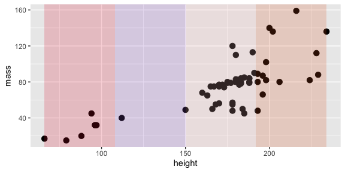

```r
RectangleFiller(plotExample, c("#e32636", "#9966cc", "#f4c2c2", "#e16827"))
```

## rgbToHex()

This package comes with rgbToHex, converting rgb colors into hex code colors.

```r
rgbToHex(c("(225, 104, 39)","(60, 90, 202)"))
```

```
#> [1] "#e16827" "#3c5aca"
```

## Gogh Painting Sets

The dataset goghPaintingSets contains a list of every Gogh painting, some information about them, and a set of colors randomly pulled from it. This can be used to make your own Gogh themed colorsets.

```r
knitr::kable(head(goghPaintingSets,4))
```

| name | colors | year | genre | style | link |
| --- | --- | --- | --- | --- | --- |
| The Goat Herd | (‘#241E26’, ‘#3F3A40’, ‘#8B888C’, ‘#D8D7D9’, ‘#BEBABF’) | 1862 | sketch and study | Realism | https://uploads6.wikiart.org/images/vincent-van-gogh/the-goat-herd-1862.jpg!Large.jpg |
| Dog | (‘#BFB6AE’, ‘#D9D0C7’, ‘#F2EAE4’, ‘#736968’, ‘#261E1E’) | 1862 | animal painting | Post-Impressionism | https://uploads3.wikiart.org/images/vincent-van-gogh/dog(1).jpg!Large.jpg |
| Milk Jug | (‘#0D0B0B’, ‘#403C3D’, ‘#F2E8DF’, ‘#D9D0C7’, ‘#8C8887’) | 1862 | still life | Realism | https://uploads5.wikiart.org/images/vincent-van-gogh/milk-jug.jpg!Large.jpg |
| Barn and Farmhouse | (‘#F2EADF’, ‘#BFBBB8’, ‘#736E6C’, ‘#0D0A0A’, ‘#403B3B’) | 1864 | landscape | Post-Impressionism | https://uploads0.wikiart.org/images/vincent-van-gogh/barn-and-farmhouse(1).jpg!Large.jpg |

## gogh_palettes_pop

For ease of use, gogh_palettes_pop is a list of color palettes from the most well known Gogh paintings.

`cafeTerrace` = ‘#2A6BBF’, ‘#3F6CA6’, ‘#F2C84B’, ‘#D99036’, ‘#BF6734’

[figure not shown]

### The palettes can be used in graphs as follows:

#### `scale_color_gogh` Continuous

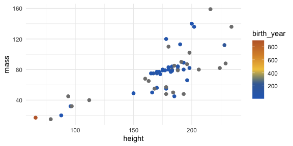

```r
plotExample2 <- ggplot(exampleData, aes(x = height, y = mass, color = birth_year)) +
  geom_point(size = 2) +
  scale_color_gogh(palette = "cafeTerrace", discrete = FALSE) +
  theme_minimal()
plotExample2
```

#### `scale_color_gogh` Discrete

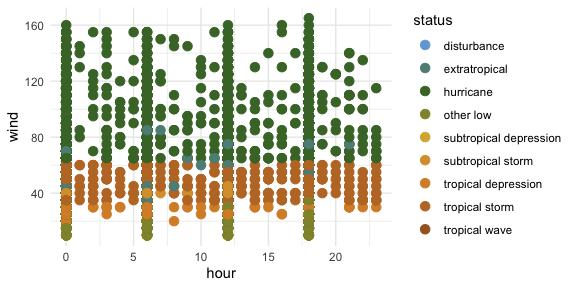

```r
ggplot(storms, aes(x = hour, y = wind, color = status)) +
  geom_point(size = 3) +
  scale_color_gogh(palette = "wheatField", discrete = TRUE, reverse=FALSE) +
  theme_minimal()
```

#### `scale_fill_gogh` Discrete

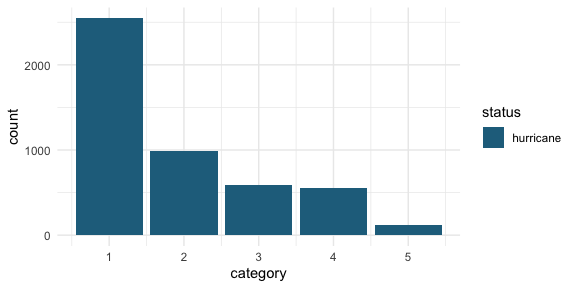

```r
ggplot(storms, aes(x = category, fill = status)) +
  geom_bar() +
  scale_fill_gogh(palette = "almondBlossoms", discrete = TRUE, reverse=FALSE) +
  theme_minimal()
```